# Alien Lingua Franca

Ke “Kay” Fang, Stanford University

Monica Marion, Indiana University Bloomington

2025-06-26

# Introduction

Communication across language barriers gives rise to linguistic phenomena that defy simple models of gradual language change. Contact between different cultures can produce simplified or hybrid forms such as pidgins or vehicular languages—often referred to as “lingua franca.” The original Lingua Franca emerged as a functional language to facilitate communication across the medieval Middle East, Africa, and Europe. It developed in a decentralized manner through sustained interactions among speakers of many different languages (Bosch, 2015). The history of such cross-cultural communication methods raises broader cognitive questions about how people establish reference and reach shared understanding across linguistic differences. Previous research has explored the dynamics of reference and consensus through interactive tasks where participants agree on descriptions (Hawkins et al., 2020) or group and label ambiguous symbols (Guilbeault et al., 2021).

To model aspects of this process, we imagine a set of planets in a distant galaxy connected by faster-than-light travel. Humans have terraformed and colonized these planets, and their movement across vast distances has resulted in a gradient of mutually related languages. More specifically, these languages exist along a continuum of similarity, where languages spoken on nearby planets are more alike. We assume cross-linguistic correspondence: each referent has one word in every language, and these words consistently refer to the same thing. In this setting, representatives from many different planets convene for interplanetary trade, yet none share a common language.

We utilize a Bayesian cognitive model to explore how effective communication might arise in such a cross-linguistic context. Building on reference games, we examine scenarios in which individuals from different planets speak related, but distinct, languages. A speaker’s ability to recognize or produce a referent’s label in another language depends on the linguistic distance between their languages. We compare two communication strategies: a baseline strategy where each agent speaks only their native language and tries to interpret the other’s language as a listener, and a cognitively flexible strategy in which agents expand their lexicons and use theory of mind to choose the most helpful labels.

We hypothesize that the second strategy will not only be more efficient, but will also facilitate the emergence of a “lingua franca” among the planets. In the baseline model, perfect communication requires each agent to learn the other’s entire lexicon, demanding significant interaction time and cognitive effort. In contrast, the flexible model allows agents to gradually acquire foreign terms as listeners, and later reuse these terms as speakers. Over time, agents can choose between native and non-native terms depending on which best promotes understanding. This process supports the formation of shared conventions—early stages of a “lingua franca,” or what is often called a “mixed language.”

# 2. Formalization

Building on our interplanetary trade scenario, we now introduce the mathematical machinery that will allow us to model how agents communicate across related—but distinct—languages, infer one another’s meanings, and gradually converge on shared conventions.

## 2.1 Basic Definitions

### 2.1.1 Action Spaces

We begin by defining the core sets of our model:

- **Languages**

Let

$$\mathcal{L} = \{\,a, b, \dots, k\}$$

denote the set of $K$ languages spoken across the colonized planets. These are arranged along a similarity continuum (nearby planets speak more similar languages).

- **Referents**

Let

$$\mathcal{R} = \{\,r_1, r_2, \dots, r_n\}$$

be the set of $n$ possible objects or concepts (e.g., trade goods) that agents wish to refer to.

- **Utterances**

Each language $i\in\mathcal{L}$ has a lexicon

$$U_i = \{\,u_{1,i}, u_{2,i}, \dots, u_{n,i}\},$$

and the global set of utterances is $\displaystyle \mathcal{U} = \bigcup_{i\in\mathcal{L}} U_i$.

We assume **cross‐linguistic correspondence**: for every referent $r_j$, the words $u_{j,a}, u_{j,b}, \dots, u_{j,k}$ all denote the same underlying object $r_j$.

### 2.1.2 Decodability Matrix (Initial Beliefs)

To capture how well a listener of language $j$ can interpret an utterance from language $i$ without any prior interactions, we define the decodability of a label in one language to another as: $D_{i,j}\bigl(u_{n,i}\to r_m\bigr) = P_L(r_{m} | u_{n,i})$. That is, given the utterance from a language $i$, the probability that a listener whose language is $j$ will guess the referent being $r_m$.

The specific value of $D_{i,j}\bigl(u_{n,i}\to r_m\bigr)$ is defined as:

1. **Linguistic Distance**

$$d(i,j) \;=\; \bigl|\mathrm{pos}(i) - \mathrm{pos}(j)\bigr|$$

where $\mathrm{pos}(\cdot)$ is the location of each language along the underlying similarity axis.

2. **Similarity function**

To model the similarity between languages, we use an exponential decay function so that mutual intelligibility falls off smoothly with distance as common choices in language‐change models.

$$s(i,j) \;=\; \exp\!\bigl(-\,d(i,j)/\tau\bigr),
\quad \tau>0$$

3. **Decodability matrix**

For the decodability, we assume that a native listener always perfectly maps the label in their native langaue to the correct referent ($u_{n,i}\to r_n$ with probability 1), and to any other $r_m$ with probability 0. For **cross‐language** ($i\neq j$) decodability, we assume a mixture of a similarity‐based signal $\alpha\, \cdot \; s(i,j)$ focused on the correct referent, and a background confusion $(1 - \alpha) \cdot b_{n,m}$ (uniform noise) with the parameter $\alpha$ trades off reliance on signal versus noise. Formally:

$$D_{i,j}(u_{n,i}\to r_m) =
\begin{cases}
1, & \text{if }i=j\text{ and }m=n,\\[6pt]
0, & \text{if }i=j\text{ and }m\neq n,\\[6pt]
\alpha\,s(i,j)\,\delta_{n,m}
\;+\;(1-\alpha)\,b_{n,m},
& \text{if }i\neq j,
\end{cases}$$

$$\text{with } \displaystyle\sum_{m=1}^n D_{i,j}(u_{n,i}\to r_m)=1.$$

### 2.2 Baseline Dyadic Dynamics

We first analyze a simple **baseline** in which when agent is selected as speaker, they only their native language, and when they are selected as listener, their task is to decode the label to referent in foreign language.

#### 2.2.1 Agent Roles

- **Speaker** $S_i$: an agent whose native language is $i$.
- **Listener** $L_j$: an agent whose native language is $j$.

Each round:

1. A target referent $r_n$ is randomly selected.
2. Speaker $S_i$ produces its native label $u_{n,i}$.
3. Listener $L_j$ interprets $u_{n,i}$ with

$$P_{L_j}(r_m\mid u_{n,i})
= D_{i,j}(u_{n,i}\to r_m).$$

4. A binary feedback $f\in\{0,1\}$ (0 as incorrect and 1 as correct) is returned:

$$f = \mathbf{1}[\,\text{listener’s choice}=r_n\,].$$

5. Listener $L_j$ updates its belief about the association between the foreign-language label and selected referent via Bayes’ rule:

$$D_{i,j}^{\text{new}}(u_{n,i}\!\to r_m)
\propto
D_{i,j}^{\text{old}}(u_{n,i}\!\to r_m)
\times
P\bigl(f\mid u_{n,i}\to r_m\bigr),$$

where

$$P(f=1\mid u_{n,i}\to r_m)=\delta_{m,n},
\quad
P(f=0\mid u_{n,i}\to r_m)=1-\delta_{m,n}.$$

Concretely:

- If $f=1$ (correct referent is selected): the listener sets all mass on the correct mapping.
- If $f=0$ (the referent selected is incorrect): the listener rules out the mistaken mapping and renormalizes.

### 2.3 Adaptive (Theory‐of‐Mind) Dyadic Dynamics

Here each agent not only listens and updates but also 1) learns labels in foreign language and 2) strategically chooses utterances based on a model of the other’s understanding.

#### 2.3.1 Agent Types & State

- **Agent A:** $A_i$ (native $i$).
- **Agent B:** $B_j$ (native $j$).

Each agent $A_i$ (as well as $B_j$ symmetrically) maintains:

1. There own decodability matrix $D^{(A)}_{j,i}(u\to r_m),$ that model how $A_i$ with native language $i$ decodes $u\in U_j$.
2. Model of other’s beliefs

$$\hat D^{(A)}_{i,j}(u\to r_m),$$

modeling how $A_i$ believes $B_j$ interprets $u\in U$.

3. Available lexicon

$$\mathcal{L}^{(A)}_i
\subseteq \bigcup_{k\in\mathcal{L}} U_k,$$

the set of utterances $A_i$ can produce (initially $\mathcal{L}^{(A)}_i = U_i$).

##### Initial Conditions

All beliefs start from the same similarity‐based prior:

$$D^{(A)}_{j,i}(u_{n,j}\!\to r_m)
= \hat D^{(A)}_{i,j}(u_{n,i}\!\to r_m)
= \alpha\, \cdot s(j,i)\,\delta_{n,m}
+ (1-\alpha) \cdot \,b_{n,m}.$$

#### 2.3.2 Turn Structure

At each round $t$:

1. Role assignment: $\mathrm{Speaker}(t)\in\{A_i,B_j\}$, the other is listener.
2. Referent selection:

$$r_n \sim \mathrm{Uniform}(\mathcal{R}).$$

3. Speaker Produce Utterance

$$u_{A} \sim P_{A_i}(u\mid r_n)_{u \in \mathcal{L}^{(B)}}$$

4. Listener Select Answering Referent

$$r_{B} \sim D^{(B)}_{i,j}(u\to r_m)$$

5. Feedback Given
- Listener will update their belief on the association between the foreign label and the answered referent.
- Speaker will also update their their internal model of the listener using the feedback.

#### 2.3.3 Speaker Policy (if $A$ is speaker):

- **Utterance utility**

For any $u\in\mathcal{L}^{(A)}_i$ that denotes $r_n$, define $\pi_{A_i}(u,r_n)=\hat D^{(A)}_{i,j}(u\to r_n)$.

- **Softmax choice**

$$P_{A_i}(u\mid r_n)
= \frac{\exp\bigl(\pi_{A_i}(u,r_n)/\beta\bigr)}
{\sum_{u':\,u'\mapsto
r_n}\exp\bigl(\pi_{A_i}(u',r_n)/\beta\bigr)},$$

with rationality $\beta>0$.

- **Model update after feedback (Theory of Mind)**

After observing feedback $f$, $A_i$ updates their internal model using the same rule:

$$\hat{D}_{i,j}^{(A),\text{new}}(u\to r_m)
\propto
\hat{D}_{i,j}^{(A),\text{old}}(u\to r_m)
\times
P\bigl(f \mid u\to r_m\bigr).$$

#### 2.3.4 Listener Policy (if $B$ is listener):

- **Interpretation:**

$$P_{B_j}(r_m\mid u)
= D^{(B)}_{i,j}(u\to r_m).$$

# 3. Results

## 3.1 Convergence Speed

We quantify **efficiency** by the number of rounds required for a pair to reach perfect accuracy (100 % success rate).

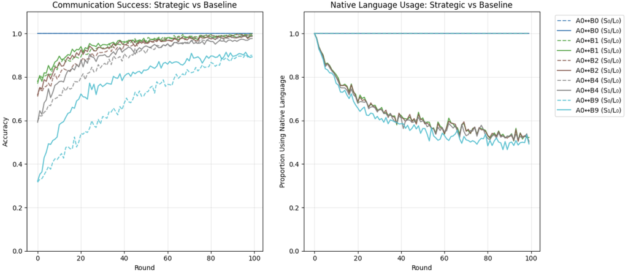

## 3.2 Emergence of a Mixed Language

Next, we ask: **for each of the 10 referents, do the two agents settle on the same language?**  
High agreement on a shared language *per referent*—where different referents may each converge on different languages—signals the formation of a coordinated “mixed language.”

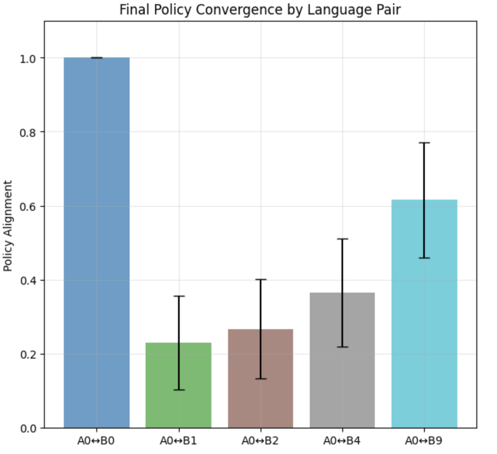

- As linguistic distance **increases**, agents become **more likely** to converge on a **shared language for each referent**—often one that is neither speaker’s native code.
- When two languages are **very similar**, the high base‐rate of comprehension lowers the incentive to borrow, so each agent typically defaults to their own labels.
- Conversely, for **very distant** languages, low initial intelligibility forces a choice: either **fully learn** the partner’s lexicon (expensive) or **coordinate around** a smaller set of high‐utility terms drawn from both sides—thus giving rise to an emergent lingua franca.

**In summary:**

1. The Theory‐of‐Mind strategy delivers **faster convergence** and **greater efficiency**, especially as language distance grows.
2. Only the ToM policy actively **expands its lexicon** and **strategically employs foreign terms**.
3. Wider linguistic gaps amplify the drive to form a **mixed code**, balancing learning costs against communicative success.

# 4. Future Directions

One natural extension is to move beyond dyads and embed agents in larger **interaction networks**. When many speakers—each with a different native language—must coordinate, the cognitive cost of fully learning every foreign lexicon grows superlinearly. We therefore expect the Bayesian Theory‐of‐Mind (BToM) strategy to yield an even larger efficiency gain in multi‐agent settings. Moreover, the **topology** of the network (who interacts with whom) and the **distribution** of native speakers will shape not only how many distinct mixed languages emerge, but also the **lexical composition** of each: for instance, whether a given mixed language borrows predominantly from one hub language or evenly from multiple sources.

To bring the model closer to real‐world language contact, we can initialize it with **empirically derived similarity metrics** and speaker distributions. For example, one could simulate a “dominant‐language” scenario—mirroring the global prevalence of modern English—or a **polyglot environment** in which no single language predominates, thereby fostering a true lingua franca drawn from several tongues. By importing lexical‐similarity scores from resources such as the UKC Similarity Database of Modern Lexicons (Bella et al., 2021) into our exponential kernel $s(i,j)$, we can ground the abstract distance function in real data. Incorporating socio‐historical factors—such as power asymmetries or migration patterns (Jourdan, 1991)—would further illuminate how social structure and force dynamics drive the birth and stabilization of vehicular codes.

Finally, several **additional refinements** could enrich the framework. Allowing **heterogeneous learning rates** would reflect differences in cognitive capacity or motivation to adopt foreign labels. And relaxing the one‐to‐one word‐referent assumption to model **polysemy** or **semantic drift** would capture more of the complexity found in natural pidgins, creoles, and lingua francas. Together, these avenues promise to connect our formal machinery more tightly with the diverse realities of cross‐linguistic communication.

## References

1. **Bosch, C.** (2015). On the Conceptual History of the Term *Lingua Franca*. *Apples – Journal of Applied Language Studies*, 9(1), 71–85. https://doi.org/10.17011/apples/2015090104
2. **Bella, G.**, **Batsuren, K.**, & **Giunchiglia, F.** (2021). A Database and Visualization of the Similarity of Contemporary Lexicons. In *Proceedings of the 24th International Conference on Text, Speech, and Dialogue* (TSD 2021), Olomouc, Czech Republic.
3. **Guilbeault, D.**, et al. (2021). Experimental Evidence for Scale-Induced Category Convergence across Populations. *Nature Communications*, 12(1), 327. https://doi.org/10.1038/s41467-020-20037-y
4. **Hawkins, R. D.**, et al. (2020). Characterizing the Dynamics of Learning in Repeated Reference Games. *arXiv* preprint arXiv:1912.07199. https://doi.org/10.48550/arXiv.1912.07199
5. **Jourdan, C.** (1991). Pidgins and Creoles: The Blurring of Categories. *Annual Review of Anthropology*, 20, 187–209.